# How a First Seed Falls

## An insight to the Milwaukee Bucks losing the first round of the 2023 NBA playoffs

### By: Justin Pratama and Ojas Malghan

### Motivation

The Milwaukee Bucks have been the best team in recent years and are considered to be one of the most exciting to watch. Their superstar, Giannis Antetokounmpo is considered to be one of the most entertaining athletes of our time, standing at a massive 7'0 feet tall and being able to reach the rim from the three-point line in two strides. Surrounding Giannis is a cast of stars, including Jrue Holiday and Khris Middleton, players that could support a dynasty for years to come.

Ever since the 2017 NBA season, the Bucks have routinely made the playoffs. Year by year, as their starting lineup solidified, their stars trained, and their chemistry improved, they climbed to 1st seed of the Eastern conference and since 2019, they have achieved it continuously. They would even culminate in winning the NBA finals and the Larry O'Brien championship trophy in the 2021 season.

In the 2023 season, the Bucks were looking to achieve the success that they first obtained in 2021 and achieve another championship ring. They would end the season with the best record in the league at 58 wins and 24 losses. With hopes high and a championship over the horizon, the first seed geared up to go into a deep playoff run and secure a second championship within three years. Little did they know, they would make NBA history.

As the sixth instance in the NBA's 76-year history in which a first-seeded team lost to the eight-seeded (lowest in the playoff bracket) team, the opposing team being the Miami Heat in the first round. We wanted to look into the factors that led to this untimely defeat and how they infamously made NBA history. To find this we first read articles from [USA Today](https://www.usatoday.com/story/sports/nba/columnist/jeff-zillgitt/2023/04/26/bucks-lose-first-round-series-heat/11749703002/), [SB Nation](https://www.sbnation.com/nba/2023/4/27/23700258/milwaukee-bucks-nba-playoffs-giannis-stats-budenholzer-breakdown), and [The Athletic](https://theathletic.com/4473274/2023/05/04/milwaukee-bucks-miami-heat-aldridge/). We found that these were some factors to consider:

1. The phenomenal plays of Jimmy Butler of the Miami Heat
2. A superstar injured, the team without Giannis

Our team will use data to analyze how each of these factors led to the downfall of the Milwaukee Bucks and hope that viewers can learn through Python methods how data can solve real-world dilemmas.

## Analysis 1: The phenomenal plays of Jimmy Butler of the Miami Heat

There are times in sports when a player trains hard, wins many games, and then loses to a player that trained just as hard but is simply more talented. Sometimes losing is outside of the control of the team, and the other team just played a better game. Coming into this series, the Miami Heat were the underdogs, but this was not superstar Jimmy Butler's first rodeo. We will look into the data to try to understand how this league veteran was able to beat one of the league's premier superstars, Giannis Antetokounmpo, and how he compares to others. Let's analyze his performance.

### Data Collection

The data that we will use is from [Basketball Reference](https://www.basketball-reference.com/), which details the intricate history of every season that Jimmy Butler has played and his playoff data. Through the conversion of raw data from the website into .csv files, we were able to extract what we needed for this examination.

### Data Processing

Below we will read the .csv files that our team made and observe some of the data between Jimmy Butler and the Miami Heat. Using the Pandas library in Python, we can see the different stats through tables. (See [here](https://pandas.pydata.org/docs/user_guide/index.html#user-guide) for documentation)

```python
import pandas as pd
import matplotlib.pyplot as plt
jb_stats = pd.read_csv("./Data/jbdata.csv")
jb_playoff = pd.read_csv("./Data/jbplayoff.csv")
```

### Jimmy Butler Data

Note: I have to drop the 8 and 9 columns as they show seasonal splits between the two different teams he played for in the 2019 season, which is not necessary as Basketball Reference already gives you a seperate row for the totals of both teams he played on.

```python
jb_stats = jb_stats.drop([8, 9])
jb_stats
```

|  | Season | Age | Team | Lg | Pos | G | GS | MP | FG | FGA | ... | FT% | ORB | DRB | TRB | AST | STL | BLK | TOV | PF | PTS |
| --- | --- | --- | --- | --- | --- | --- | --- | --- | --- | --- | --- | --- | --- | --- | --- | --- | --- | --- | --- | --- | --- |
| 0 | 2011-12 | 22 | CHI | NBA | SG | 42 | 0 | 8.5 | 0.8 | 1.9 | ... | 0.768 | 0.5 | 0.8 | 1.3 | 0.3 | 0.3 | 0.1 | 0.3 | 0.5 | 2.6 |
| 1 | 2012-13 | 23 | CHI | NBA | SF | 82 | 20 | 26.0 | 2.9 | 6.2 | ... | 0.803 | 1.7 | 2.3 | 4.0 | 1.4 | 1.0 | 0.4 | 0.8 | 1.2 | 8.6 |
| 2 | 2013-14 | 24 | CHI | NBA | SG | 67 | 67 | 38.7 | 4.1 | 10.3 | ... | 0.769 | 1.3 | 3.6 | 4.9 | 2.6 | 1.9 | 0.5 | 1.5 | 1.6 | 13.1 |
| 3 | 2014-15 | 25 | CHI | NBA | SG | 65 | 65 | 38.7 | 6.5 | 14.0 | ... | 0.834 | 1.8 | 4.1 | 5.8 | 3.3 | 1.8 | 0.6 | 1.4 | 1.7 | 20.0 |
| 4 | 2015-16 | 26 | CHI | NBA | SG | 67 | 67 | 36.9 | 7.0 | 15.4 | ... | 0.832 | 1.2 | 4.2 | 5.3 | 4.8 | 1.6 | 0.6 | 2.0 | 1.9 | 20.9 |
| 5 | 2016-17 | 27 | CHI | NBA | SF | 76 | 75 | 37.0 | 7.5 | 16.5 | ... | 0.865 | 1.7 | 4.5 | 6.2 | 5.5 | 1.9 | 0.4 | 2.1 | 1.5 | 23.9 |
| 6 | 2017-18 | 28 | MIN | NBA | SG | 59 | 59 | 36.7 | 7.4 | 15.6 | ... | 0.854 | 1.3 | 4.0 | 5.3 | 4.9 | 2.0 | 0.4 | 1.8 | 1.3 | 22.2 |
| 7 | 2018-19 | 29 | TOT | NBA | SF/SG | 65 | 65 | 33.6 | 6.4 | 13.9 | ... | 0.855 | 1.9 | 3.4 | 5.3 | 4.0 | 1.9 | 0.6 | 1.5 | 1.7 | 18.7 |
| 10 | 2019-20 | 30 | MIA | NBA | SF | 58 | 58 | 33.8 | 5.9 | 13.1 | ... | 0.834 | 1.8 | 4.8 | 6.7 | 6.0 | 1.8 | 0.6 | 2.2 | 1.4 | 19.9 |
| 11 | 2020-21 | 31 | MIA | NBA | SF | 52 | 52 | 33.6 | 7.0 | 14.2 | ... | 0.863 | 1.8 | 5.1 | 6.9 | 7.1 | 2.1 | 0.3 | 2.1 | 1.4 | 21.5 |
| 12 | 2021-22 | 32 | MIA | NBA | SF | 57 | 57 | 33.9 | 7.0 | 14.5 | ... | 0.870 | 1.8 | 4.1 | 5.9 | 5.5 | 1.6 | 0.5 | 2.1 | 1.5 | 21.4 |
| 13 | 2022-23 | 33 | MIA | NBA | SF | 64 | 64 | 33.4 | 7.5 | 13.9 | ... | 0.850 | 2.2 | 3.7 | 5.9 | 5.3 | 1.8 | 0.3 | 1.6 | 1.3 | 22.9 |

12 rows × 30 columns

### Jimmy Butler playoff stats

```python
jb_playoff
```

|  | Season | Age | Tm | Lg | Pos | G | GS | MP | FG | FGA | ... | FT% | ORB | DRB | TRB | AST | STL | BLK | TOV | PF | PTS |
| --- | --- | --- | --- | --- | --- | --- | --- | --- | --- | --- | --- | --- | --- | --- | --- | --- | --- | --- | --- | --- | --- |
| 0 | 2011-12 | 22 | CHI | NBA | SG | 3 | 0 | 1.3 | 0.0 | 0.0 | ... | NaN | 0.0 | 0.0 | 0.0 | 0.0 | 0.0 | 0.0 | 0.0 | 0.3 | 0.0 |
| 1 | 2012-13 | 23 | CHI | NBA | SF | 12 | 12 | 40.8 | 4.2 | 9.6 | ... | 0.818 | 0.8 | 4.4 | 5.2 | 2.7 | 1.3 | 0.5 | 1.3 | 2.2 | 13.3 |
| 2 | 2013-14 | 24 | CHI | NBA | SG | 5 | 5 | 43.6 | 4.4 | 11.4 | ... | 0.783 | 1.2 | 4.0 | 5.2 | 2.2 | 1.2 | 0.0 | 0.6 | 2.6 | 13.6 |
| 3 | 2014-15 | 25 | CHI | NBA | SG | 12 | 12 | 42.2 | 7.8 | 17.8 | ... | 0.819 | 1.5 | 4.1 | 5.6 | 3.2 | 2.4 | 0.8 | 1.8 | 2.3 | 22.9 |
| 4 | 2016-17 | 27 | CHI | NBA | SF | 6 | 6 | 39.8 | 7.7 | 18.0 | ... | 0.809 | 1.5 | 5.8 | 7.3 | 4.3 | 1.7 | 0.8 | 2.5 | 1.7 | 22.7 |
| 5 | 2017-18 | 28 | MIN | NBA | SG | 5 | 5 | 34.0 | 5.6 | 12.6 | ... | 0.833 | 0.6 | 5.4 | 6.0 | 4.0 | 0.8 | 0.2 | 1.0 | 1.8 | 15.8 |
| 6 | 2018-19 | 29 | PHI | NBA | SF | 12 | 12 | 35.1 | 6.6 | 14.6 | ... | 0.875 | 1.8 | 4.3 | 6.1 | 5.2 | 1.4 | 0.6 | 1.8 | 1.7 | 19.4 |
| 7 | 2019-20 | 30 | MIA | NBA | SF | 21 | 21 | 38.4 | 6.9 | 14.0 | ... | 0.859 | 2.2 | 4.3 | 6.5 | 6.0 | 2.0 | 0.7 | 2.8 | 1.8 | 22.2 |
| 8 | 2020-21 | 31 | MIA | NBA | SF | 4 | 4 | 38.5 | 4.8 | 16.0 | ... | 0.727 | 1.5 | 6.0 | 7.5 | 7.0 | 1.3 | 0.3 | 2.3 | 1.5 | 14.5 |
| 9 | 2021-22 | 32 | MIA | NBA | SF | 17 | 17 | 37.0 | 9.8 | 19.3 | ... | 0.841 | 2.4 | 4.9 | 7.4 | 4.6 | 2.1 | 0.6 | 1.5 | 1.5 | 27.4 |
| 10 | 2022-23 | 33 | MIA | NBA | SF | 7 | 7 | 37.9 | 12.6 | 22.3 | ... | 0.757 | 2.1 | 4.3 | 6.4 | 4.4 | 1.6 | 0.6 | 2.3 | 1.7 | 34.4 |

11 rows × 30 columns

By the looks of it, we were able to get a clean dataset for Jimmy Butler's regular season stats and playoff stats. Now lets analyze what it means and how impactful Jimmy Butler truly is.

### Exploratory analysis & Data viz

Now, given all of the data that we needed about Jimmy Butler and his time in the Miami Heat, we will look into his impact on the court and how his play has improved within the time on the team. To start we will look into his performance in the regular season and how it compares to when playoffs start.

Using the Matplotlib is a Python library (See [here](https://matplotlib.org/) for documentation), we will create graphs to display the statistics between his playoff stats and regular season stats over the years. First starting off with points per game, the primary part(points) of winning NBA games.

We will also use the Numpy library to help us set the amount of ticks we want in the x-coordinates.(See [here](https://numpy.org/) for documentation)

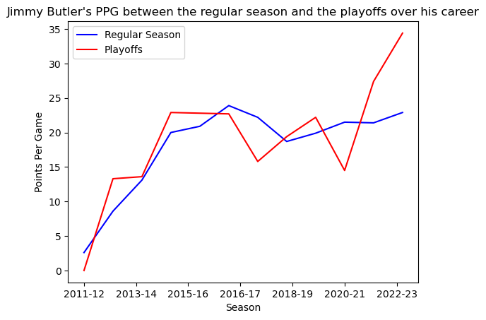

```python
import numpy as np
fig, ax = plt.subplots()
ax.plot(jb_stats["Season"], jb_stats["PTS"],color='blue', label='Regular Season')
ax.plot(jb_playoff["Season"], jb_playoff["PTS"],color='red', label='Playoffs')
ax.set_xticks(np.arange(0, len(jb_stats), 1.8))
ax.legend()
plt.title("Jimmy Butler's PPG between the regular season and the playoffs over his career")
plt.xlabel("Season")
plt.ylabel("Points Per Game")
plt.show()
```

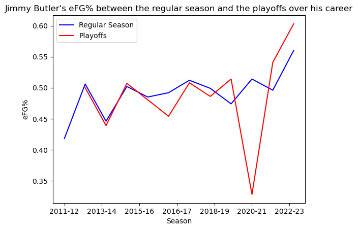

```python
fig, ax = plt.subplots()
ax.plot(jb_stats["Season"], jb_stats["eFG%"],color='blue', label='Regular Season')
ax.plot(jb_playoff["Season"], jb_playoff["eFG%"],color='red', label='Playoffs')
ax.set_xticks(np.arange(0, len(jb_stats), 1.8))
ax.legend()
plt.title("Jimmy Butler's eFG% between the regular season and the playoffs over his career")
plt.xlabel("Season")
plt.ylabel("eFG%")
plt.show()
```

From an analysis of his points per game (the average of the number of points a player obtains per game in a season), we can see that in most cases, Jimmy Butler has stayed pretty consistent between the playoffs and the regular season. This is with exceptions to seasons where he underperformed in points (2018 & 2021) and seasons where he goes beyond expectation (2023).

We also analyzed his performance in eFG% or effective field goal percentage which is a metric used to determine how many of a player's shot attempts are successful. Again, similar consistency with his regular season stats except for the 2021 season, where he lost in the first round and was thoroughly defended. Though, his efficiency in the playoffs has shot up compared to the regular season in the past two years.

In order to truly understand the impact that Jimmy Butler had, we would also need to look into his advanced stats. A set of statistics that analyze a player's impact on the court, hidden behind the player's choices. For instance, assisting one teammate into an open basket instead of taking a 3pt shot contested would yield positives on the advanced stats. Let's examine Jimmy Butler's advanced stats.

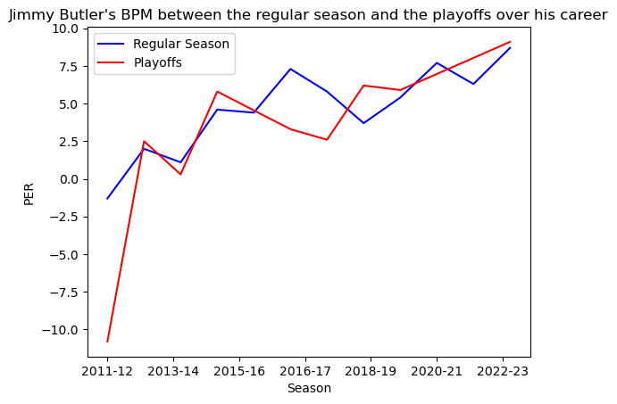

```python
jb_radv = pd.read_csv("./Data/jbdataadv.csv")
jb_padv = pd.read_csv("./Data/jbplayoffadv.csv")
#Seasonal split
jb_radv = jb_radv.drop([8,9])
jb_padv = jb_padv.drop([8,9])

fig, ax = plt.subplots()
ax.plot(jb_radv["Season"], jb_radv["BPM"],color='blue', label='Regular Season')
ax.plot(jb_padv["Season"], jb_padv["BPM"],color='red', label='Playoffs')
ax.set_xticks(np.arange(0, len(jb_stats), 1.8))
ax.legend()
plt.title("Jimmy Butler's BPM between the regular season and the playoffs over his career")
plt.xlabel("Season")
plt.ylabel("PER")
plt.show()
```

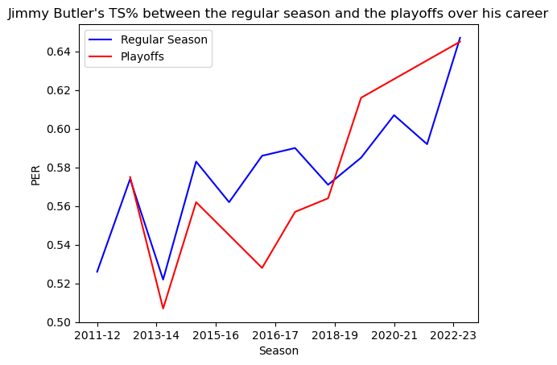

```python
fig, ax = plt.subplots()
ax.plot(jb_radv["Season"], jb_radv["TS%"],color='blue', label='Regular Season')
ax.plot(jb_padv["Season"], jb_padv["TS%"],color='red', label='Playoffs')
ax.set_xticks(np.arange(0, len(jb_stats), 1.8))
ax.legend()
plt.title("Jimmy Butler's TS% between the regular season and the playoffs over his career")
plt.xlabel("Season")
plt.ylabel("PER")
plt.show()
```

Again we see that Jimmy Butler also has a consistent BPM, with a dip in playoffs but mainly due to early exits, or not making it at all.BPM stands for Box Plus/Minus and it is a statistic used in basketball to estimate a player's contribution to his team's performance, relative to the league average. The league average is 0, a positive BPM indicates a player is performing above most NBA players, and a negative indicates a below-average player.

Jimmy Butler also has an interesting ts%, with a dip in playoffs but mainly due to early exits, not making it at all, or being under more pressure to score in the playoffs. True Shooting Percentage (TS%) is a statistic in the NBA that measures a player's shooting efficiency by taking into account all types of field goal attempts (including three-point shots, two-point shots, and free throws).

### Hypothesis Testing

We want to find out how much of an impact in efficiency Jimmy Butler had on his team and how it is opposed to other teams. It is not just to find how well Jimmy played in order to benefit the team but how efficiently he played. His totals seem to be consistent with his career in the regular season, but in the playoffs, they become more sporadic.

We decided to create a null hypothesis in which Jimmy Butler is playing much better in the playoffs in recent years than he does in the regular season. This is because, in all the data that we have shown above, we see that Jimmy Butler has had large spikes recently in his career.

Using the PPG, eFG%, TS%, and BPM, we will determine how much better Jimmy Butler is in the playoffs through standard deviations of the mean of his regular season performance.

```python
#Determine the means
rs_ppg_mean = jb_stats["PTS"].mean()
rs_efg_mean = jb_stats["eFG%"].mean()
rs_ts_mean = jb_radv["TS%"].mean()
rs_bpm_mean = jb_radv["BPM"].mean()
#Determine the standard deviations
rs_ppg_std = jb_stats["PTS"].std()
rs_efg_std = jb_stats["eFG%"].std()
rs_ts_std = jb_radv["TS%"].std()
rs_bpm_std = jb_radv["BPM"].std()
#Use playoff data
ps_ppg = jb_playoff["PTS"]
ps_efg = jb_playoff["eFG%"]
ps_ts = jb_padv["TS%"]
ps_bpm = jb_padv["BPM"]

print("Points Per Game: \n" + str((ps_ppg - rs_ppg_mean)/rs_ppg_std))

print("Efficient Field Goal %: \n" + str((ps_efg - rs_efg_mean)/rs_efg_std))

print("True Shooting Percentage: \n" + str((ps_ts - rs_ts_mean)/rs_ts_std))

print("Box Plus/Minus: \n" + str((ps_bpm - rs_bpm_mean)/rs_bpm_std))
```

```
Points Per Game:
0    -2.760777
1    -0.718032
2    -0.671956
3     0.756430
4     0.725712
5    -0.334058
6     0.218866
7     0.648917
8    -0.533725
9     1.447584
10    2.522713
Name: PTS, dtype: float64
Efficient Field Goal %:
0          NaN
```

[output cut: 33 more lines]

### Thoughts

Based on some of our calculations, Jimmy has performed better in recent years. His standard deviations are mostly positive in recent years, so long as he makes the playoffs and has a run into the second round. With spot number 10 being the latest season, the farthest deviation into the positive is his eFG% which goes far from the mean at 3.130008 in the 2023 season. Our null hypothesis holds.

### ML/Visualizations

Ultimately we want to see how efficient Jimmy Butler truly is. By doing this, we want to determine his PER based on the factors that we discussed previously. Essentially PER (Player Efficiency Rating) is a measure of a player's overall performance. It takes into account a player's positive contributions, such as scoring, assists, and rebounds, while also accounting for negative contributions, such as missed shots and turnovers. As seen in [this](https://bleacherreport.com/articles/759714-nba-thoughts-which-stat-is-most-important-in-the-nba) article, PER is one of the most important stats to consider in an NBA player to determine their worth and effects on the court.

To determine how good Jimmy is, we took data on all the players in the current playoffs from Basketball Reference and spliced the regular and advanced stats to use as a dataset. Using a Linear Regression model and help from this sklearn information [site](https://scikit-learn.org/stable/modules/generated/sklearn.model_selection.train_test_split.html), we want to determine how PPG, eFG%, TS% and BPM effect PER.

```python
from sklearn.model_selection import train_test_split
from sklearn.linear_model import LinearRegression
from sklearn.metrics import r2_score
#Takes in the data
nba_data = pd.read_csv("./Data/2023_nba_ml_data.csv")

# Split the dataset into training and testing sets
train_data, test_data = train_test_split(nba_data, test_size=0.2)

# Define the features and target variables
features = ['PTS', 'eFG%','TS%','BPM']
target = 'PER'

# Train the model
model = LinearRegression()
model.fit(train_data[features], train_data[target])

test_predictions = model.predict(test_data[features])

# Calculate the accuracy of the model
accuracy = r2_score(test_data[target], test_predictions)

print('The accuracy of the model is:', accuracy)
```

```
The accuracy of the model is: 0.9516633046923378
```

We see that this is fairly accurate, with most runs of this code being between the high 80s to the high 90s.

Now we will plot to see who is performing well this postseason.

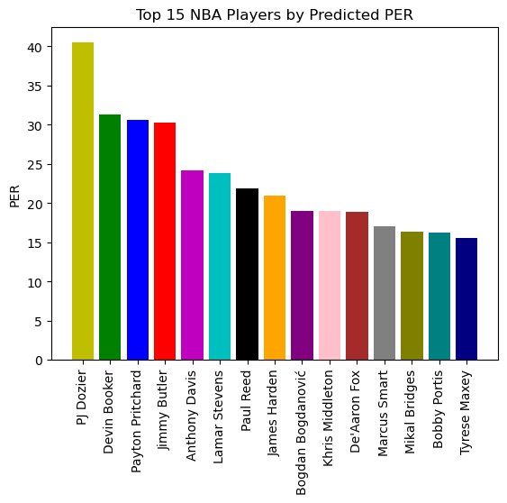

```python
test_data_sorted = test_data.iloc[test_predictions.argsort()[::-1]]

# Select the top 15 players
top_15 = test_data_sorted.nlargest(15, 'PER')

colors = ['y', 'g', 'b', 'r', 'm', 'c', 'k', 'orange', 'purple', 'pink', 'brown', 'gray', 'olive', 'teal', 'navy']

# Plot the PER scores of the top 15 players
plt.bar(top_15['Player'], top_15['PER'], color=colors)
plt.xticks(rotation=90)
plt.ylabel('PER')
plt.title('Top 15 NBA Players by Predicted PER')
plt.show()
```

Note: These findings are during the second round of the postseason as the 2023 season has not concluded, please keep this in mind as you look at this data past the 2023 season.

### Insight

From our standard deviation, we found that Jimmy Butler has been playing at a pace that is beyond what he is playing before in the playoffs. This is while having the fourth-highest PER of postseason teams based on our findings.

## Analysis 2: A superstar injured, the team without Giannis

### Data Processing

Below we will read the .csv files that our team made and observe some of the data between Giannis's playoff occurances and his team's performance when he was not present. Using the Pandas library in Python, we can see the different stats through tables. (See [here](https://pandas.pydata.org/docs/user_guide/index.html#user-guide) for documentation)

```python
import pandas as pd
import numpy as np
import matplotlib.pyplot as plt
game_stats_mil = pd.read_csv("./Data/MilwaukeePlayOffLog.csv")
giannis_playoff = pd.read_csv("./Data/Giannis.csv")
game_stats_miami= pd.read_csv("./Data/MilwaukeePlayOffLogMiamiData.csv")
```

```python
giannis_playoff
```

|  | Rk | G | Date | Age | Tm | Opp | WinLoss | GS | MP | FG | ... | DRB | TRB | AST | STL | BLK | TOV | PF | PTS | GmSc | +/- |
| --- | --- | --- | --- | --- | --- | --- | --- | --- | --- | --- | --- | --- | --- | --- | --- | --- | --- | --- | --- | --- | --- |
| 0 | 1 | 1.0 | 2023-04-16 | 28-131 | MIL | MIA | -13 | 1 | 10:50 | 2.0 | ... | 2.0 | 3.0 | 0.0 | 0.0 | 0.0 | 1.0 | 2.0 | 6.0 | 2.7 | -9.0 |
| 1 | 2 | NaN | 2023-04-19 | 28-134 | MIL | MIA | 16 | Inactive | NaN | NaN | ... | NaN | NaN | NaN | NaN | NaN | NaN | NaN | NaN | NaN | NaN |
| 2 | 3 | NaN | 2023-04-22 | 28-137 | MIL | MIA | -22 | Inactive | NaN | NaN | ... | NaN | NaN | NaN | NaN | NaN | NaN | NaN | NaN | NaN | NaN |
| 3 | 4 | 2.0 | 2023-04-24 | 28-139 | MIL | MIA | -5 | 1 | 38:27:00 | 12.0 | ... | 7.0 | 10.0 | 13.0 | 1.0 | 2.0 | 6.0 | 3.0 | 26.0 | 23.1 | 1.0 |
| 4 | 5 | 3.0 | 2023-04-26 | 28-141 | MIL | MIA | 2 | 1 | 42:10:00 | 14.0 | ... | 16.0 | 20.0 | 3.0 | 0.0 | 0.0 | 7.0 | 4.0 | 38.0 | 20.6 | -8.0 |

5 rows × 29 columns

Note: I had to drop the data in the columns named below since they are not of importance to us. I also dropped two rows, the games he did not play in. We need this data to compare his performance in the games he did play to the time he played.

```python
giannis_playoff.drop(columns=['Age','Tm','Opp'],inplace=True)
giannis_playoff.drop([1,2], inplace=True)
giannis_playoff.drop(columns=['Date'],inplace=True)
giannis_playoff
```

|  | Rk | G | WinLoss | GS | MP | FG | FGA | FG% | 3P | 3PA | ... | DRB | TRB | AST | STL | BLK | TOV | PF | PTS | GmSc | +/- |
| --- | --- | --- | --- | --- | --- | --- | --- | --- | --- | --- | --- | --- | --- | --- | --- | --- | --- | --- | --- | --- | --- |
| 0 | 1 | 1.0 | -13 | 1 | 10:50 | 2.0 | 4.0 | 0.500 | 0.0 | 0.0 | ... | 2.0 | 3.0 | 0.0 | 0.0 | 0.0 | 1.0 | 2.0 | 6.0 | 2.7 | -9.0 |
| 3 | 4 | 2.0 | -5 | 1 | 38:27:00 | 12.0 | 22.0 | 0.545 | 0.0 | 1.0 | ... | 7.0 | 10.0 | 13.0 | 1.0 | 2.0 | 6.0 | 3.0 | 26.0 | 23.1 | 1.0 |
| 4 | 5 | 3.0 | 2 | 1 | 42:10:00 | 14.0 | 27.0 | 0.519 | 0.0 | 2.0 | ... | 16.0 | 20.0 | 3.0 | 0.0 | 0.0 | 7.0 | 4.0 | 38.0 | 20.6 | -8.0 |

3 rows × 25 columns

### 2022-23 Milwaukee Bucks Playoff Game Log

```python
game_stats_mil
```

|  | Rk | G | W/L | Tm | Opp | FG | FGA | FG% | 3P | 3PA | ... | FT | FTA | FT% | ORB | TRB | AST | STL | BLK | TOV | PF |
| --- | --- | --- | --- | --- | --- | --- | --- | --- | --- | --- | --- | --- | --- | --- | --- | --- | --- | --- | --- | --- | --- |
| 0 | 1 | 1 | L | 117 | 130 | 45 | 91 | 0.495 | 11 | 45 | ... | 16 | 22 | 0.727 | 8 | 38 | 29 | 3 | 4 | 13 | 22 |
| 1 | 2 | 2 | W | 138 | 122 | 53 | 99 | 0.535 | 25 | 49 | ... | 7 | 8 | 0.875 | 9 | 45 | 35 | 9 | 4 | 11 | 16 |
| 2 | 3 | 3 | L | 99 | 121 | 38 | 85 | 0.447 | 15 | 39 | ... | 8 | 12 | 0.667 | 8 | 37 | 22 | 7 | 3 | 18 | 15 |
| 3 | 4 | 4 | L | 114 | 119 | 42 | 97 | 0.433 | 13 | 40 | ... | 17 | 20 | 0.850 | 16 | 46 | 28 | 10 | 6 | 14 | 20 |
| 4 | 5 | 5 | L | 126 | 128 | 42 | 91 | 0.462 | 14 | 33 | ... | 28 | 45 | 0.622 | 10 | 56 | 20 | 4 | 1 | 15 | 21 |

5 rows × 21 columns

### Giannis PLayoff Game Analysis

### Exploratory analysis & Data viz

Now, given all of the data that we needed about Giannis and his stats in the games he played, we need to analyze it.

We will look into the impact his minutes played had on the total points in the game, and the minutes played impact on the final score differential. Meaning, how much did his team win or lose by.

Using the Matplotlib is a Python library (See [here](https://matplotlib.org/) for documentation), we will create graphs to display the statistics between his playoff stats.

We will also use the Numpy library to help us generate a line of best fit.(See [here](https://numpy.org/) for documentation)

We will also be using the Pandas library in Python, we can see the different stats through tables and create a dataframe (See [here](https://pandas.pydata.org/docs/user_guide/index.html#user-guide) for documentation)

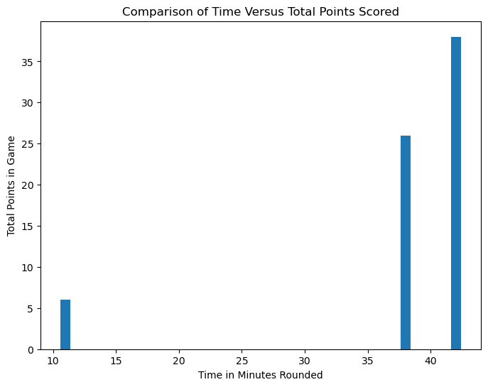

```python
# data needed to create integer values of time rounded to nearest whole number

data = [11,38,42]

# creates dataframe with data and creates a column called MP
df = pd.DataFrame(data, columns=['MP'])

# makes a bar chart with x as time and y as points
fig, ax = plt.subplots(figsize=(8, 6))

# sets labels accordingly

ax.bar(df['MP'], giannis_playoff['PTS'])
ax.set_xlabel('Time in Minutes Rounded')
ax.set_ylabel('Total Points in Game')
ax.set_title('Comparison of Time Versus Total Points Scored')
plt.show()
```

In the bar graph above we can tell that the more time he spent playing, the more he scored. This logically makes sense, but now we have data above to support this claim. He only played in three games, so there are only three bars in the graph above. We can see that in the first game he only played for around 11 minutes and did not score even half of what he did in the later two games.

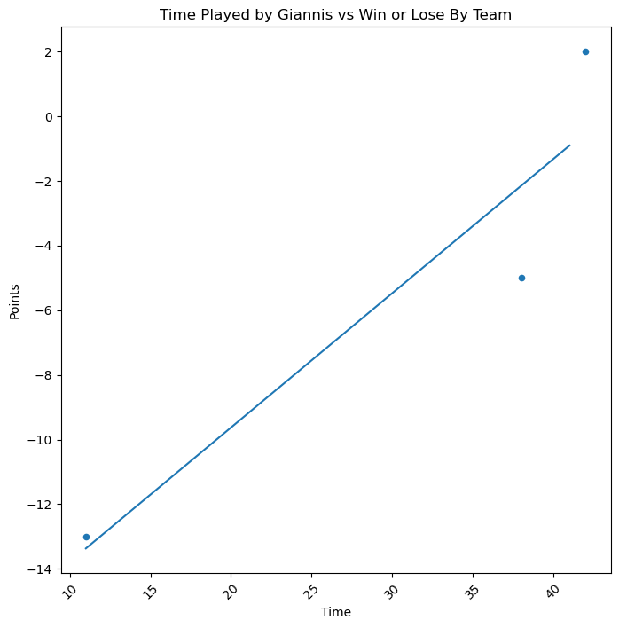

```python
# first analyze Giannis Data Alone
fig, ax = plt.subplots(figsize=(8, 8))

# Create a scatter plot for MP vs Win and Loss
ax.scatter(df['MP'], giannis_playoff['WinLoss'], s=20)

ax.set_title('Time Played by Giannis vs Win or Lose By Team')
plt.xticks(fontsize=10, rotation=45)
plt.yticks(fontsize=10)
plt.xlabel('Time')
plt.ylabel('Points')

# Create a line of best fit
x = np.arange(df['MP'].min(), df['MP'].max())
m, b = np.polyfit(df['MP'], giannis_playoff['WinLoss'], 1)

# PLot that line
ax.plot(x, m*x+b)

#show the plot
plt.show()
```

In the graph above, we are able to get more of a confirmation that when he is playing, he is impacting the team in a big way. While we only have three games available to graph, we can clearly see an increasing slope. Meaning, the more time he spent playing, the closer the gap was if they lost. The more he played, the lower the point differential was at the end of the game if they were losing, and higher the point differential if they were winning. We only have one match showing a win. However, if we can predict what would happen at more time, we would state that the gap would be larger.

### Analysis of 2022-23 Milwaukee Bucks Game Log

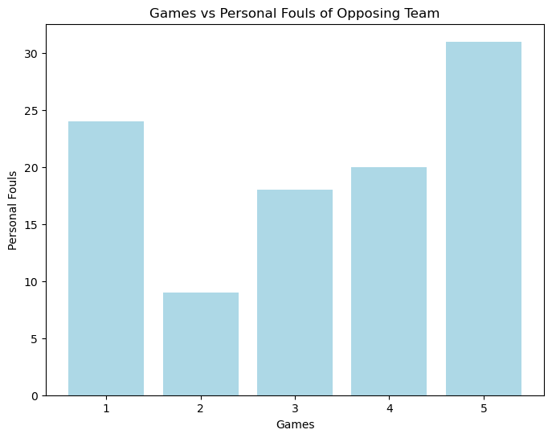

```python
fig, ax = plt.subplots(figsize=(8, 6))

# sets labels accordingly

ax.bar(game_stats_miami['G'], game_stats_miami['PF'], color="lightblue")
ax.set_xlabel('Games')
ax.set_ylabel('Personal Fouls')
ax.set_title('Games vs Personal Fouls of Opposing Team')
plt.show()
```

We know from before that Giannis barely played in the first game. We know that he did not play in 2 or third games. He only had significant playtime in games 4 and 5. If we see the bar graph above, we can see that in the games where he played the most, there were somewhat higher personal fouls that opposing team caused. This benfits Giannis's team.

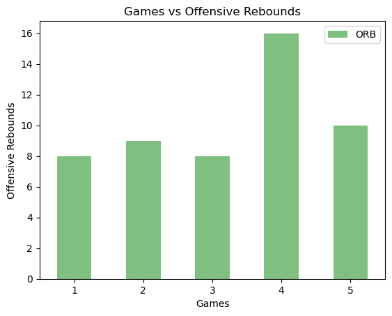

```python
# show game stats
game_stats_mil


# create a bar graph with x as games and y as offensive rebounds
ax = game_stats_mil.plot(x='G', y='ORB', kind='bar', color='green', alpha=0.5)

# set the title and axis labels
ax.set_title('Games vs Offensive Rebounds')
ax.set_xlabel('Games')
ax.set_ylabel('Offensive Rebounds')
ax.set_xticklabels(game_stats_mil['G'], rotation=0)

plt.show()
```

We know from before that Giannis barely played in the first game. We know that he did not play in 2 or third games. He only had significant playtime in games 4 and 5. If we see the bar graph above, the games he did play there were more rebounds than the games he did not play. That means, he was helping the team get more possession of the ball, thus overall benefitting the team.

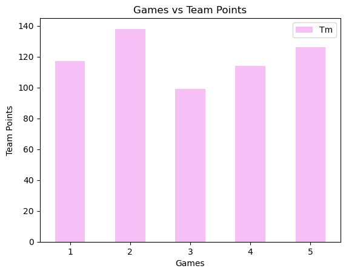

```python
# show game stats
game_stats_mil


# create a bar graph with x as games areboundsnd y as offensive
ax = game_stats_mil.plot(x='G', y='Tm', kind='bar', color='violet', alpha=0.5)

# set the title and axis labels
ax.set_title('Games vs Team Points')
ax.set_xlabel('Games')
ax.set_ylabel('Team Points')
ax.set_xticklabels(game_stats_mil['G'], rotation=0)

plt.show()
```

We can see here, besides for game 2, the games he played resulted in higher points for his team.

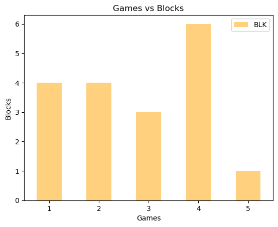

```python
# show game stats
game_stats_mil


# create a bar graph with x as games areboundsnd y as offensive
ax = game_stats_mil.plot(x='G', y='BLK', kind='bar', color='orange', alpha=0.5)

# set the title and axis labels
ax.set_title('Games vs Blocks')
ax.set_xlabel('Games')
ax.set_ylabel('Blocks')
ax.set_xticklabels(game_stats_mil['G'], rotation=0)

plt.show()
```

Once again, we can see that in the games he did play, 1,4,5 there were equal, if not more blocks except for game 5. Game 5 is an outlier in this case. In games 1 and 4, there were equal or more blocks than in game 2 and 3.

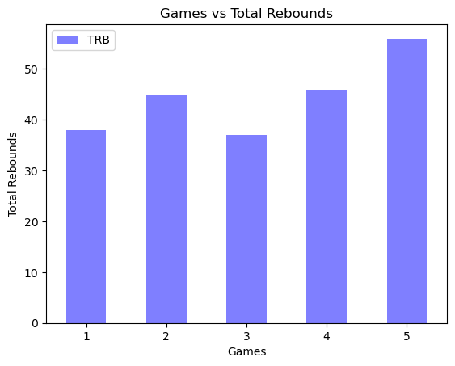

```python
# show game stats
game_stats_mil


# create a bar graph with x as games areboundsnd y as offensive
ax = game_stats_mil.plot(x='G', y='TRB', kind='bar', color='blue', alpha=0.5)

# set the title and axis labels
ax.set_title('Games vs Total Rebounds')
ax.set_xlabel('Games')
ax.set_ylabel('Total Rebounds')
ax.set_xticklabels(game_stats_mil['G'], rotation=0)

plt.show()
```

Except for game 2, we can see that there were more total rebounds in the games he played compared to the games he did not play.

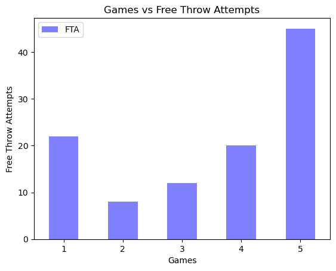

```python
# show game stats
game_stats_mil


# create a bar graph with x as games areboundsnd y as offensive
ax = game_stats_mil.plot(x='G', y='FTA', kind='bar', color='blue', alpha=0.5)

# set the title and axis labels
ax.set_title('Games vs Free Throw Attempts')
ax.set_xlabel('Games')
ax.set_ylabel('Free Throw Attempts')
ax.set_xticklabels(game_stats_mil['G'], rotation=0)

plt.show()
```

Once again, we can see that in the games he did play in, he made sure to have more of presence as we can see by the data above. The data above shows that in Games 1,4,5 there were more free throw attempt them the games he was not in.

## Conclusion

### Final Thoughts

Just to recap, first, we looked into the performance of superstar Jimmy Butler and how his performance was abnormally better in recent seasons than in his earlier career. His play is at an all-time high career-wise, and we showed it through a number of plots to display his highs in PPG, eFG%, BPM, and TS%.

We also determined that through his recent playoff performances, he has performed above the average mean of his career, showing that he plays more effectively in the playoffs. Using a linear regression model, we calculated his PER relative to the displayed stats in the plots before. With his performance as high as ever, we saw that Jimmy Butler turning it up for the playoffs led to a major aspect of the Bucks losing the series.